# Transmission of SARS-CoV-2 variants in Switzerland

Date of report: 5 March 2021

Download report as PDF

< [Coronavirus Disease 2019 (COVID-19) Resources at ISPM](https://ispmbern.github.io/covid-19/)

## Contributors

- Martina Reichmuth, Emma Hodcroft, Julien Riou, Christian L. Althaus, [Institute of Social and Preventive Medicine](https://www.ispm.unibe.ch), University of Bern, Bern, Switzerland
- Manuel Schibler, Isabella Eckerle, Laurent Kaiser, [Geneva University Hospitals](https://www.hug.ch/en/), Geneva, Switzerland
- Franziska Suter, [Institute for Infectious Diseases](https://www.ifik.unibe.ch), University of Bern, Bern, Switzerland
- Michael Huber, Alexandra Trkola, [Institute of Medical Virology](https://www.virology.uzh.ch), University of Zurich, Zurich, Switzerland
- Barbara Hasse, Jakob Nilsson, [University Hospital Zurich](https://www.usz.ch), Zurich, Switzerland
- Roberto Buonomano, [Spital Limmattal](https://www.spital-limmattal.ch), Schlieren, Switzerland
- Alexander Wepf, Urs Karrer, Kantonsspital Winterthur, Winterthur, Switzerland
- Richard Neher, [Biozentrum](https://www.biozentrum.unibas.ch/research/researchgroups/overview/unit/neher/), University of Basel, Basel, Switzerland

Contact: christian.althaus@ispm.unibe.ch

## Summary

- **The proportion of SARS-CoV-2 variants (501Y, B.1.1.7) among confirmed cases has increased rapidly in Switzerland.**
- **The increase in the proportion of SARS-CoV-2 variants (501Y, B.1.1.7) in Geneva is around two weeks ahead of the rest of Switzerland.**
- **We estimate an increase in transmissibility of around 50% for the new SARS-CoV-2 variants (501Y, B.1.1.7).**
- **The findings underline the importance of efficient control measures in order to prevent an increase in SARS-CoV-2 incidence in Switzerland.**

## Results

Three recently detected [variants](https://covariants.org) (B.1.1.7, B.1.351, P.1) of SARS-CoV-2 have been detected in various countries worldwide including Switzerland. We aim at tracking the spread of these variants in the cantons of Geneva, Bern, and Zurich, and in Switzerland overall. As a comparison, we also provide an analysis of the spread of B.1.1.7 in Denmark. Finally, we estimate the current proportion of the variants for a given region and their increased transmissibility.

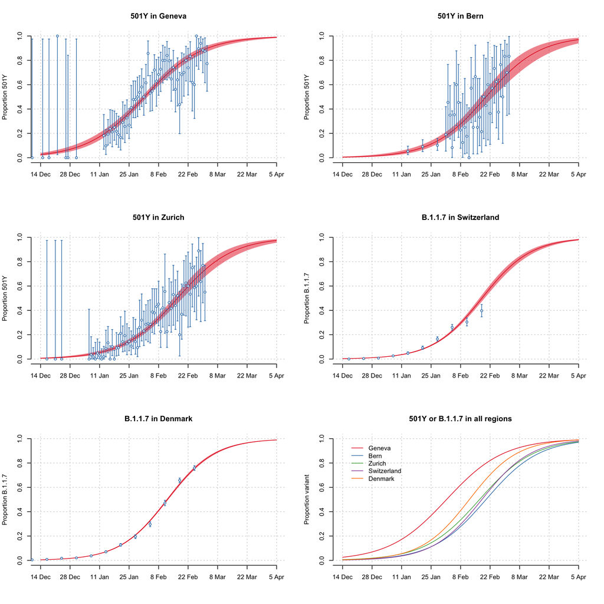

The proportion of the variants has increased rapidly in all regions (Figure 1). Fitting a logistic growth model to the data allows to quantify and project the increase in the proportion of the new variants (see Methods) (Figure 2, Table 1). Note that due to the delay from infection to sample collection, the shown increase and the estimated proportions of the new variants reflect the epidemic situation from around one week ago.

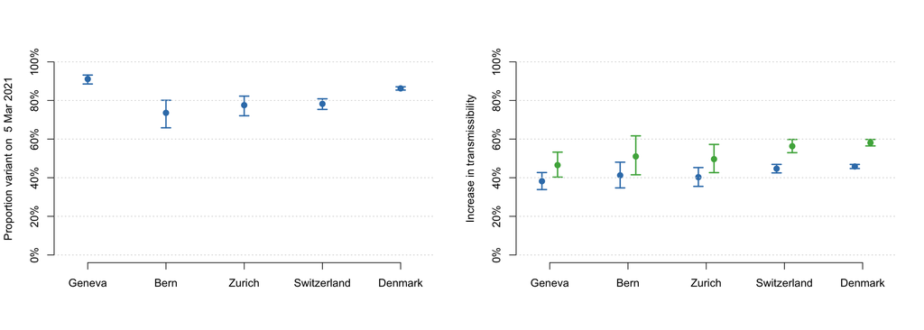

**Figure 2. Estimated proportion of the variant (left) and increase in transmissibility (right).** The increase in transmissibility is estimated assuming the effective reproduction number of the wild-type $R_w \approx 1$ and an exponentially (blue) and delta (green) distributed generation time of 5.2 days ([Ganyani et al.](https://doi.org/10.2807/1560-7917.ES.2020.25.17.2000257)). Error bars correspond to 95% confidence intervals.

**Table 1. Estimated proportion of the variant and increase in transmissibility.** The increase in transmissibility is estimated assuming the effective reproduction number of the wild-type $R_w \approx 1$ and an exponentially (blue) and delta (green) distributed generation time of 5.2 days ([Ganyani et al.](https://doi.org/10.2807/1560-7917.ES.2020.25.17.2000257)).

| Region | Variant | Proportion at 5 Mar 2021 | Increase in transmissibility |
| --- | --- | --- | --- |
| Geneva | 501Y | 91% (89%-93%) | 38% (34%-43%) - 47% (40%-53%) |
| Bern | 501Y | 74% (66%-80%) | 41% (35%-48%) - 51% (42%-62%) |
| Zurich | 501Y | 78% (72%-82%) | 40% (36%-45%) - 50% (43%-57%) |
| Switzerland | B.1.1.7 | 78% (75%-81%) | 45% (42%-47%) - 56% (53%-60%) |
| Denmark | B.1.1.7 | 86% (85%-87%) | 46% (45%-47%) - 58% (56%-60%) |

The estimates for the increase in transmissibility are in good agreement with earlier findings for B.1.1.7 in the UK and other countries ([Volz et al.](https://www.medrxiv.org/content/10.1101/2020.12.30.20249034v2), [Davies et al.](https://doi.org/10.1126/science.abg3055), [Leung et al.](https://www.eurosurveillance.org/content/10.2807/1560-7917.ES.2020.26.1.2002106)). Taken together, these findings underline the importance of efficient control measures in order to prevent an increase in SARS-CoV-2 incidence in Switzerland.

## Methods

### Data

We use data sets from the following five regions for our analysis (download [here](https://github.com/ISPMBern/covid-19/tree/master/variants/data)):

- **Geneva, Switzerland:** We use samples that were sent to the [Geneva University Hospitals](https://www.hug.ch/en/) for primary diagnosis of SARS-CoV-2. All positives were re-screened for 501Y using RT-PCR (mostly B.1.1.7). To cover the period of November and December 2020, we use sequence data from randomly chosen samples from Geneva that were submitted to [GISAID](https://www.gisaid.org) by the [Swiss Viollier Sequencing Consortium](https://bsse.ethz.ch/cevo/research/sars-cov-2/swiss-sequencing-consortium---viollier.html) from ETH Zurich.
- **Bern, Switzerland:** We use samples from SARS-CoV-2-positive cases that were re-screened for 501Y using RT-PCR at the [Institute for Infectious Diseases](https://www.ifik.unibe.ch), [University of Bern](http://www.unibe.ch).
- **Zurich, Switzerland:** We use samples from SARS-CoV-2-positive cases from the [University Hospital Zurich](https://www.usz.ch) and test centers at [Limmattal Hospital](https://www.spital-limmattal.ch) in Schlieren (ZH) and [Spital Männedorf](https://www.spitalmaennedorf.ch) that were re-screened for 501Y using RT-PCR at the [Institute of Medical Virology](https://www.virology.uzh.ch), [University of Zurich](http://www.uzh.ch). In addition, we use SARS-CoV-2-positive samples from [Kantonsspital Winterthur](https://www.ksw.ch) and its walk-in test center that were re-screened for 501Y using RT-PCR.
- **Switzerland:** We use data on the frequency of B.1.1.7 among randomly chosen SARS-CoV-2 samples that underwent genetic characterization and are provided by the [Swiss Viollier Sequencing Consortium](https://bsse.ethz.ch/cevo/research/sars-cov-2/swiss-sequencing-consortium---viollier.html) from ETH Zurich and the [Swiss National COVID-19 Science Task Force](https://sciencetaskforce.ch).
- **Denmark:** We use data on the frequency of B.1.1.7 among sequenced genomes from the [Danish Covid-19 Genome Consortium](https://www.covid19genomics.dk/home).

### Model

Competitive growth between variant and non-variant (‘wild-type’) strains of SARS-CoV-2 can be described by the following two ordinary differential equations:
$$\begin{align}
\frac{dW}{dt} &= \beta S W - \gamma W, \\
\frac{dV}{dt} &= \beta (1 + \tau) S V - \gamma V,
\end{align}$$
where $W$ and $V$ are individuals infected with wild-type and variant, respectively, and $S$ the population of susceptibles. For the variant, the transmission rate $\beta$ is increased by the factor $1 + \tau$ and both strains are cleared at rate $\gamma$. For $\tau > 0$, one can easily show that the proportion of the new variant among all infections increases according to logistic growth:
$$\begin{align}
p(t) &= \frac{V(t)}{W(t) + V(t)} = \frac{1}{1 + \kappa e^{- \rho t}},
\end{align}$$
where $\kappa = W(0)/V0$ and $\rho = \beta \tau S$, i.e., the difference in the net growth rates between the variant and the wild-type. $\rho$ can be directly estimated by fitting a logistic growth model (binomial regression) to the proportion of the new variant. The increased transmissibility of the variant is then given by $\tau = \rho/(\beta S)$. Since the effective reproduction number of the wild-type is $R_w = \beta S/\gamma$ and the generation time is $D = 1/\gamma$, we obtain $\tau = \rho D/R_w$. For a situation where $R_w \approx 1$, we can simplify to $\tau \approx \rho D$. This derivation assumes an exponentially distributed generation time. For a delta distributed generation time, one finds that $\tau \approx e^{\rho D} - 1$.

## Funding

- European Union’s Horizon 2020 research and innovation programme - project [EpiPose](https://www.uhasselt.be/epipose) (No 101003688)
- Swiss National Science Foundation (grant 196046)